# MSDS Final Project - H&M

Rochelle Rafn

2022-08-03

# 50 year olds shopping at H&M? What’s that all about?

## Question

For those who are unfamiliar with H&M, it’s a fast fashion retailer known for its affordable, youthful and trendy styles. I’ve always loved staying current with fashion and who knows? Maybe when I’m 50 I will still be shopping at H&M or similar stores, like Zara. However, even in my 30s, if I venture into H&M I feel noticeably older than everyone else there. So, why are there twice as many 50 year olds as people my age shopping at H&M, and where are they? This led me to question, does age actually matter for trendy stores like H&M that are perceived as ‘younger’? Are the different generational age groups actually purchasing different things? Spoiler alert, they are not. So what does this mean? Who are these 50 year olds and why are their purchase habits similar to the 20 somethings?

## Context

This question is important for demographic and marketing research. Traditionally we believe that location, age, gender all matter and make a difference. And… they do. But, context is everything. In order to make appropriate and informed decisions it is important to do proper analysis to make sure we’re not assuming something about someones age or gender that ends up being incorrect. For instance, are frequent shoppers purchasing items for themselves or someone else? That is the beauty of data. We can dive in the deep end and really see what is beneath the surface of human bias.

## Summary

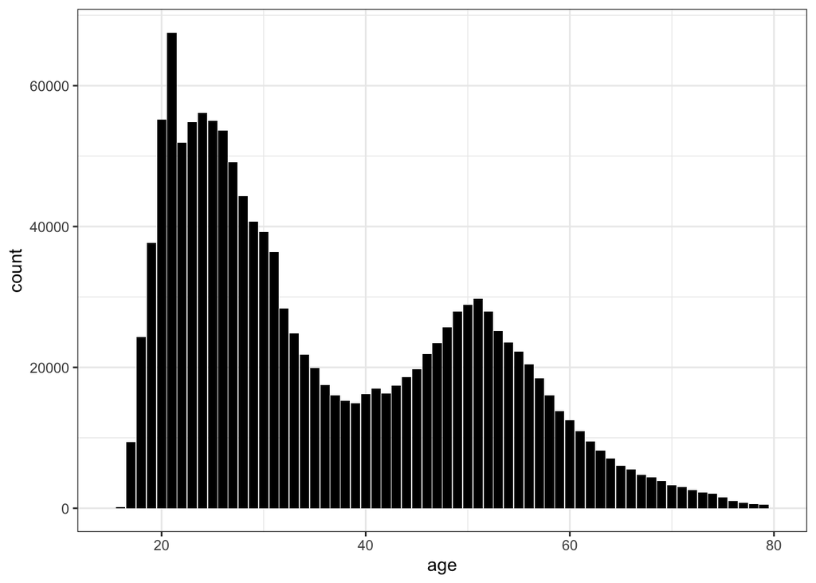

My immediate thought was that it is a group of ‘young at heart’ and fashion conscious 50 year olds. Then, as I looked a little closer at the distribution I did the math and realized the peaks moved at very similar shapes within about 30 years of each other. That logically seems pretty close to a parent-child age gap. Leading me to question, who are they actually buying for? My assumption is if the 50 year olds are actually purchasing for their children, the items would be virtually the same. If they are actually purchasing for themselves, I should be able to find some key indicators to predict age.

## Data Description

The data set I’m analyzing comes directly from H&M spanning 1.3 million customers (ages 16-99), 53 online markets, 4,850 retail stores and 31 million transactions over 2 years. It came with three relational data frames with details on Customers, Articles (clothing items) and Transactions.

## Exploratory Data Analysis

For my exploration I decided to make age, or age group, the outcome variable. The mystery of this second curve was just too interesting to me. How can we predict the difference between the young and mature generations? Or can we at all? To start, I split the data into the two age groups, “young” (<=39) and “mature” (>=40). This would help me get organized to see what differences I could find.

I began with the most obvious, what are the most popular items in each age group? I hoped this might show me some obvious and key differences. As we can see here, the top 3 items for both age groups are identical. However, the fourth item is different. This piqued my interest since that fourth items seems to indicate an intuitive generational difference. Mature customers purchased a basic t-shirt, where the young customers purchased a “strappy cropped” top. However, the more I dug, the less significant this difference became.

### Mature Top Items

[figure not shown]

### Young Top Items

[figure not shown]

## What about the most popular unique items in each age group?

After researching top items, I filtered down even further. I chose to compare the purchases between the two groups to find unique items. What items did the young purchase that the mature did not, and vice versa?

### Mature Unique Items

[figure not shown]

### Young Unique Items

[figure not shown]

I started to get a little excited again when I found some interesting differences between the two groups. In the top items for the “young” group there were several baby items. But then the mature group had primarily items that would be appropriate for an adult. What if each group is purchasing for either themselves and/or their own children. For the mature it would make sense because they now have adult children, meaning they would have no need to purchase baby clothes. There were also a lot of underwear purchases in the top 20 for the “mature” group, but none in the top 20 for the “young”. However, when I pulled the counts for these top unique items each was only purchased at most 86 times out of more than 21 million items purchased. Unfortunately the math here is not significant enough to consider.

## What about the top descriptive words for the unique items in each age group?

To move forward with the theme of unique items I decided to take those unique items even deeper by analyzing the descriptive words. Perhaps I can find some key descriptors within broader categories that will differentiate the two groups? Despite it appearing some items were unique to each group, they were clearly still purchasing different items with very similar descriptions. Meaning, maybe each group did not purchase the exact same item, but perhaps a similar one in a different color, graphical appearance or a similar style.

### Young Top Descriptive Words

```
##            word
## 1          body
## 2       garment
## 3  babychildren
## 4         sizes
## 5        cotton
## 6         solid
## 7        jersey
## 8          dark
## 9         light
## 10         soft
```

### Mature Top Descriptive Words

```
##            word
## 1          body
## 2       garment
## 3  babychildren
## 4      children
## 5          dark
## 6         sizes
## 7         upper
## 8         solid
## 9        jersey
## 10        front
```

As we can see from the top 10 words in each group, there are a couple of unqiue words on each side. But again, if we dig deeper we find there is no significance and zooming out shows us how similar these groups really are.

## What about percentage of descriptive words?

Circling back to the proportion of “young” versus “mature” customers, I went another level deeper. After confirming that the descriptive words are very similar, what about proportion? This is an easier way to see if certain words are more popular than others by group. Since we can’t compare the counts due to the difference in group sizes, what about the proportion in which these words are used?

Yet again we can see extremely small differences. To the point where they are almost identical. Only a 3% difference between the “young” and “mature” with the top descriptor, “solid”. From there, each word shows only a 1% or less difference.

```
##   Graphic Appearance Name Young Percent Mature Percent Percent Difference
## 1                   Solid     57.326729      54.114148          3.2125813
## 2        All over pattern     12.085263      13.278961          1.1936976
## 3                 Melange      5.609772       6.623272          1.0134998
## 4                   Denim      5.918383       6.742657          0.8242733
## 5         Other structure      2.498354       1.868411          0.6299426
## 6                    Lace      2.048154       1.506038          0.5421161
```

### What is the summary of price per age group?

```
##      Min.   1st Qu.    Median      Mean   3rd Qu.      Max.
## 0.0000339 0.0169322 0.0254068 0.0287606 0.0338814 0.5915254
```

```
##      Min.   1st Qu.    Median      Mean   3rd Qu.      Max.
## 0.0000169 0.0152373 0.0250339 0.0273048 0.0338814 0.5915254
```

### How many items are each group purchasing per transaction?

```
##    Min. 1st Qu.  Median    Mean 3rd Qu.    Max.
##     1.0     3.0     5.0     6.6     8.0   336.0
```

```
##    Min. 1st Qu.  Median    Mean 3rd Qu.    Max.
##   1.000   3.000   5.000   7.617  10.000 570.000
```